# Проект "Заведения общественного питания г.Москвы"

### Задача 5

Исследуйте рейтинг заведений. Визуализируйте распределение средних рейтингов по категориям заведений. Сильно ли различаются усреднённые рейтинги для разных типов общепита?

```python
def hist_rating(df, column, groupby, title, xlabel, ylabel, binwidth, kde=False):
    '''Функция для визуализации распределения значений с учётом категорий и линией KDE.
    Параметры:
    df - датафрейм с данными для анализа.
    column - str, название столбца, значения которого будут отображаться на графике.
    groupby - str, название столбца, по которому будет производиться группировка данных.
    binwidth - int, ширина корзины для гистограммы.
    title - str, заголовок графика.
    xlabel - str, подпись по оси X.
    ylabel - str, подпись по оси Y.
    kde - наложение графика KDE на гистограмму
    '''
    # В цикле по каждой категории заведения 'category' строим отдельную гистограмму
    for value in df[groupby].unique():
        plt.figure(figsize=(10, 4))
        # Фильтруем данные по значению столбца 'category'
        food_places.loc[df[groupby] == value, column].plot(kind='hist',
                                                           density=True,
                                                           alpha=0.5,
                                                           bins=10,
                                                           label=f'{value}',
                                                           legend=True,
                                                           color='slategray'
                                                           )
        food_places.loc[df[groupby] == value, column].plot(
            kind='kde',
            label=f'KDE {value}')

        # Настраиваем внешний вид графика и выводим его на экран
        plt.title(f'{title} "{value}"')
        plt.xlabel(xlabel)
        plt.ylabel(ylabel)
        plt.legend()
        plt.grid()
        #plt.show()
    return
```

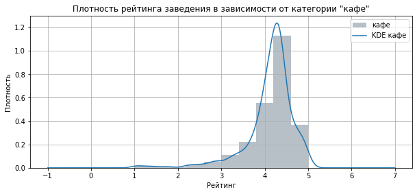

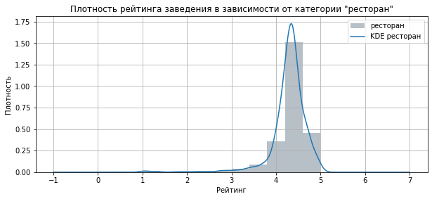

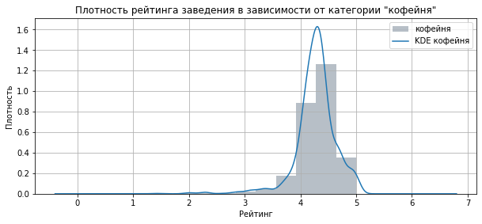

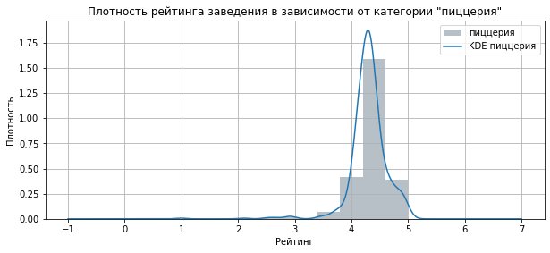

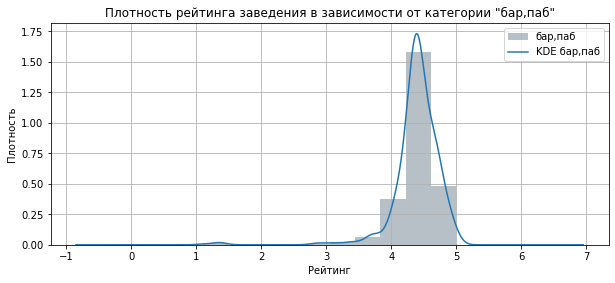

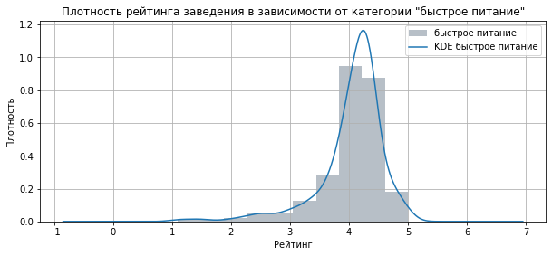

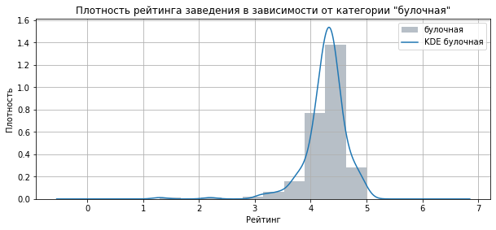

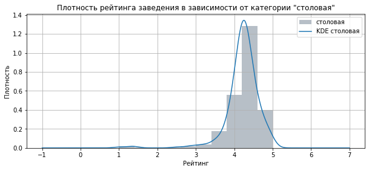

```python
# Вызываем функцию для построения отдельных гистограмм с наложением линии KDE на рейтинг для разных категорий заведений
# Строим отдельные графики, т.к. если строить на одном, то он получается очень загруженым и плохо читаемым
hist_rating(df=food_places,
            column='rating',
            groupby='category',
            binwidth=10,
            title='Плотность рейтинга заведения в зависимости от категории',
            xlabel='Рейтинг',
            ylabel='Плотность',
            kde=True)
plt.show()
```

По форме графиков типа "колокол" и группировке во всех типах заведений средних значений между 4 и 5, можно сделать вывод, что рейтинг заведений практически одинаков. В дополнение к визуализациям выведем статистику по рейтингу для каждой категории.

```python
display('Статистика по столбцу "rating" (рейтинг) для разных категорий заведений:')
display(food_places.groupby('category')['rating'].describe())
```

```
'Статистика по столбцу "rating" (рейтинг) для разных категорий заведений:'
```

| category | count | mean | std | min | 25% | 50% | 75% | max |
| --- | --- | --- | --- | --- | --- | --- | --- | --- |
| бар,паб | 764.0 | 4.387696 | 0.380392 | 1.1 | 4.3 | 4.4 | 4.6 | 5.0 |
| булочная | 256.0 | 4.268359 | 0.386303 | 1.3 | 4.2 | 4.3 | 4.4 | 5.0 |
| быстрое питание | 603.0 | 4.050249 | 0.560949 | 1.1 | 3.9 | 4.2 | 4.3 | 5.0 |
| кафе | 2376.0 | 4.124285 | 0.566001 | 1.0 | 4.0 | 4.2 | 4.4 | 5.0 |
| кофейня | 1412.0 | 4.277125 | 0.372334 | 1.4 | 4.1 | 4.3 | 4.4 | 5.0 |
| пиццерия | 633.0 | 4.301264 | 0.336162 | 1.0 | 4.2 | 4.3 | 4.4 | 5.0 |
| ресторан | 2042.0 | 4.290402 | 0.413143 | 1.0 | 4.2 | 4.3 | 4.5 | 5.0 |
| столовая | 315.0 | 4.211429 | 0.454205 | 1.0 | 4.1 | 4.3 | 4.4 | 5.0 |

### Задача 6

Изучите, с какими данными показывают самую сильную корреляцию рейтинги заведений? Постройте и визуализируйте матрицу корреляции рейтинга заведения с разными данными: его категория, положение (административный район Москвы), статус сетевого заведения, количество мест, ценовая категория и признак, является ли заведения круглосуточным. Выберите самую сильную связь и проверьте её.

```python
# в соответствии с заданием выбираем столбцы для анализа взаимосявзи рейтинга
corr_columns=['rating','category','district', 'chain', 'seats', 'price', 'is_24_7']
#вычисляем матрицу корреляции на основе коэффициента phi_k
print('Корреляционная матрица с коэффициентом phi_k для переменной "rating"(рейтинг заведения)')
correlation_matrix = food_places[corr_columns].phik_matrix(interval_cols=['rating'])
# выводим матрицу корреляции только для столбца 'rating'
correlation_matrix.loc[correlation_matrix.index !='rating'][['rating']].sort_values(by='rating', ascending=False)
```

```
Корреляционная матрица с коэффициентом phi_k для переменной "rating"(рейтинг заведения)
```

|  | rating |
| --- | --- |
| price | 0.260498 |
| is_24_7 | 0.236548 |
| district | 0.200731 |
| category | 0.189709 |
| chain | 0.107755 |
| seats | 0.000000 |

Из матрицы видим, что больше всего рейтинг зависит от ценовой политики 'price' (коэффициент phi_k=0,26). Но зависимость эта не такая сильная, т.к. далеко от 1. Для наглядности построим тепловую карту.

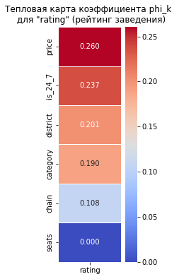

```python
# Выбираем размер
plt.figure(figsize=(2, 6))

# Сохраняем матрицу корреляции признака rating с другими признаками заведения
data_heatmap = correlation_matrix.loc[correlation_matrix.index != 'rating'][['rating']].sort_values(by='rating', ascending=False)
sns.heatmap(data_heatmap,
            annot=True, # Отображаем численные значения в ячейках карты
            fmt='.3f', # Форматируем значения корреляции: два знака после точки
            cmap='coolwarm', # Устанавливаем цветовую гамму от красного (макс. значение) к синему
            linewidths=0.5, # Форматируем линию между ячейками карты
            cbar=True # Включаем цветовую шкалу
           )

# Добавляем заголовок и подпись по оси Х
plt.title('Тепловая карта коэффициента phi_k \n для "rating" (рейтинг заведения)')
plt.xlabel('')

# Выводим график
plt.show()
```

**Вывод:** Больше всего пользовательский рейтинг зависит от ценовой политики 'price' (коэффициент phi_k=0,26). Исследуем эту связь.

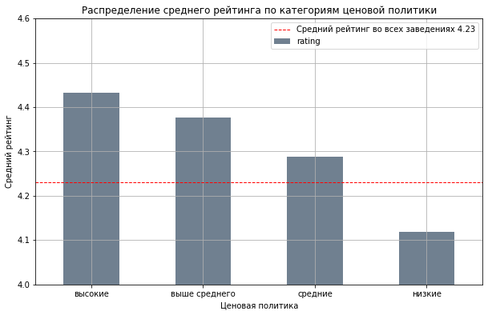

```python
#Визуализируем на столбчатой диаграмме, т.к. рейтинг у всех заведений > 4, сместим ось Y от 0 до 4 для наглядности
#сгруппируем по ценовой политике и вычислим средний рейтинг
grouped=food_places.groupby('price')['rating'].mean().sort_values(ascending=False)
grouped.plot(kind='bar',
             figsize=(10, 6),
             title='Распределение среднего рейтинга по категориям ценовой политики',
             legend=False,
             ylabel='Средний рейтинг',
             xlabel='Ценовая политика',
             ylim=[4.0,4.6],
             rot=0,
             color='slategray')

#рассчистаем средний рейтинг по всем заведениям
all_mean_rating = food_places['rating'].agg('mean')

#Наносим на график линию с значением среднего рейтинга для всех данных
plt.axhline(all_mean_rating,
            color='red',
            linestyle='--',
            linewidth=1,
            label=f'Средний рейтинг во всех заведениях {round(all_mean_rating,2)}')
plt.legend()
plt.grid()
plt.show()
```

По графику можно сказать, что чем выше ценовая политика заведения, тем выше его средний рейтинг. У заведений с ценовой политикой высокие, средние и выше среднего - средний рейтинг выше среднего рейтинга по городу. У заведений с низкими ценами - средний рейтинг - ниже среднего по городу.

В дополнение для анализа связи между категориальной и непрерывной числовой переменной можно построить параллельные диаграммы "ящиков с усами", по одному для каждой категории . Сходства и различия между уровнями категорий можно увидеть в длине и положении ящиков и усов.

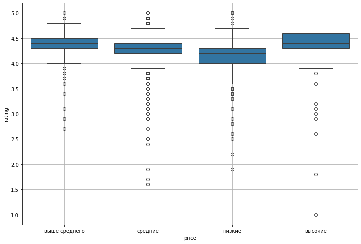

```python
#строим ящики
plt.figure(figsize=(12,8))
sns.boxplot(data=food_places, x='price', y='rating')
plt.grid()
plt.show()
```

"Усы" во всех категориях расположены симметрично, т.е. распределение рейтинга равномерно во всех категориях (ценовых политиках). Межквартильный размах визуально больше у заведений "высокие" и "низкие", что говорит о бОльшей вариативности пользовательских оценок.

Самый большой наблюдаемый максимум оценок - у заведений с "высокими" ценами. Чем ниже уровень заведения - тем ниже максимальные оеценки. То же касается и медианы рейтинга.

Интересно, что длина "усов" у категории "высокие" больше, чем у категории "выше среднего", хотя, казалосьь бы, это близкие категории. Это говорит о большем разбросе оценок в категории "высокие", что также видно по длинному хвосту слева.

### Задача 7

Сгруппируйте данные по названиям заведений и найдите топ-15 популярных сетей в Москве. Для них посчитайте значения среднего рейтинга. Под популярностью понимается количество заведений этой сети в регионе. К какой категории заведений они относятся? Результат сопроводите подходящими визуализациями.

```python
#Выбираем названия топ-15 популярных сетей общепита в переменную array_chain
array_chain=food_places['name'].loc[food_places['chain'] == True].value_counts(ascending=False).head(15)
display('Топ-15 сетевых заведений общепита: название сети/количество заведений')
display(array_chain)
```

```
'Топ-15 сетевых заведений общепита: название сети/количество заведений'
```

```
name
шоколадница                            120
домино'с пицца                          76
додо пицца                              74
one price coffee                        71
яндекс лавка                            69
cofix                                   65
prime                                   50
хинкальная                              44
кофепорт                                42
кулинарная лавка братьев караваевых     39
теремок                                 38
чайхана                                 37
cofefest                                32
буханка                                 32
му-му                                   27
Name: count, dtype: int64
```

```python
#преобразовываем серию из выборки в датафрейм
df_chain = pd.DataFrame({'name_chain': array_chain.index, 'quantity':array_chain.values})
#проверяем преобразование
display(df_chain.info())
```

```
<class 'pandas.core.frame.DataFrame'>
RangeIndex: 15 entries, 0 to 14
Data columns (total 2 columns):
 #   Column      Non-Null Count  Dtype
---  ------      --------------  -----
 0   name_chain  15 non-null     object
 1   quantity    15 non-null     int64
dtypes: int64(1), object(1)
memory usage: 372.0+ bytes
```

```
None
```

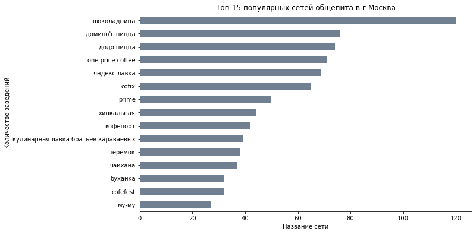

```python
# Для наглядности построим линейчатую диаграмму Топ-15
df_chain=df_chain.sort_values(by='quantity', ascending=True)
df_chain.plot(kind='barh',
              x='name_chain',
              y='quantity',
              title='Топ-15 популярных сетей общепита в г.Москва',
              legend=False,
              ylabel='Количество заведений',
              xlabel='Название сети',
              color='slategray',
              figsize=(10, 6),
              rot=0)
plt.show()
```

```python
#Добавляем колонку для среднего рейтинга в датафрейм с сетями общепита
df_chain['mean_rating'] = pd.Series(dtype='float64')
#Добавляем колонку для списка категорий заведений в сети, т.к. сеть может быть представлена не одной категорией заведений
df_chain['category'] = pd.Series(dtype='object')
#проверяем
df_chain.info()
```

```
<class 'pandas.core.frame.DataFrame'>
Index: 15 entries, 14 to 0
Data columns (total 4 columns):
 #   Column       Non-Null Count  Dtype
---  ------       --------------  -----
 0   name_chain   15 non-null     object
 1   quantity     15 non-null     int64
 2   mean_rating  0 non-null      float64
 3   category     0 non-null      object
dtypes: float64(1), int64(1), object(2)
memory usage: 600.0+ bytes
```

Теперь будем вычислять средний рейтинг сетей общепита

```python
#В цикле идем по списку сетевых заведений
for i in range(df_chain.shape[0]):
    # переменная chain - название текущей сети общепита в цикле
    chain=df_chain.iloc[i,0]
    #Для каждой сети выбираем все заведения и считаем среднее по столбцу 'rating'
    df_chain.iloc[i,2]=food_places['rating'].loc[(food_places['chain'] == True) & (food_places['name'] == chain)].mean()
    #Для каждой сети выбираем все категории заведений
    df_chain.iloc[i,3]=str(food_places['category'].loc[(food_places['chain'] == True) & (food_places['name'] == chain)].unique())
#посмотрим на результат
display(df_chain.head(15))
```

|  | name_chain | quantity | mean_rating | category |
| --- | --- | --- | --- | --- |
| 14 | му-му | 27 | 4.229630 | ['кафе' 'ресторан' 'кофейня' 'быстрое питание'... |
| 12 | cofefest | 32 | 3.984375 | ['кофейня' 'кафе'] |
| 13 | буханка | 32 | 4.396875 | ['булочная' 'кофейня' 'кафе'] |
| 11 | чайхана | 37 | 3.924324 | ['кафе' 'быстрое питание' 'ресторан'] |
| 10 | теремок | 38 | 4.123684 | ['ресторан' 'быстрое питание'] |
| 9 | кулинарная лавка братьев караваевых | 39 | 4.394872 | ['кафе'] |
| 8 | кофепорт | 42 | 4.147619 | ['кофейня'] |
| 7 | хинкальная | 44 | 4.322727 | ['быстрое питание' 'кафе' 'ресторан' 'столовая... |
| 6 | prime | 50 | 4.116000 | ['ресторан' 'кафе'] |
| 5 | cofix | 65 | 4.075385 | ['кофейня'] |
| 4 | яндекс лавка | 69 | 3.872464 | ['ресторан'] |
| 3 | one price coffee | 71 | 4.064789 | ['кофейня'] |
| 2 | додо пицца | 74 | 4.286486 | ['пиццерия'] |
| 1 | домино'с пицца | 76 | 4.169737 | ['пиццерия'] |
| 0 | шоколадница | 120 | 4.177500 | ['кофейня' 'кафе'] |

Видим, что некоторые сети представлены заведениями различных категорий.

Для оценки среднего рейтинга сетей в топ-15 построим линейчатую диаграмму.

Т.к. значения рейтинга близки между собой, для большей наглядности визуализации сместим график по оси X от 0 к 3,5.

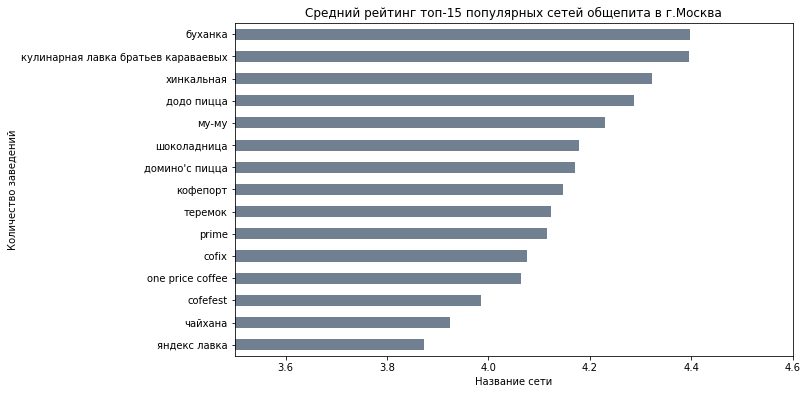

```python
#Сортируем датафрейм по значениям рейтинга
df_chain=df_chain.sort_values(by='mean_rating', ascending=True)
#строим визуализацию
df_chain.plot(kind='barh',
              x='name_chain',
              y='mean_rating',
              xlim=[3.5,4.6],
              title='Средний рейтинг топ-15 популярных сетей общепита в г.Москва',
              legend=False,
              ylabel='Количество заведений',
              xlabel='Название сети',
              color='slategray',
              figsize=(10, 6),
              rot=0)
plt.show()
```

**Вывод:** Среди представленных данных самые многочисленные сетевые заведения - шоколадница (120)(кофейня и кафе), домино'с пицца (76) (пиццерия), додо пицца (74)(пиццерия).

Наибольший пользовательский рейтинг среди сетевых заведений имеет буханка (4.4), которая представлена разными категориями заведений (булочная,кафе,кофейня). Меньше всего рейтинг у яндекс лавки - 3,8.

### Задача 8

Изучите вариацию среднего чека заведения (столбец `middle_avg_bill`) в зависимости от района Москвы. Проанализируйте цены в Центральном административном округе и других. Как удалённость от центра влияет на цены в заведениях? Результат сопроводите подходящими визуализациями.

Ограничим выборку и уберем строки с пустыми значениями 'middle_avg_bill'.

```python
bill=food_places.loc[~food_places['middle_avg_bill'].isnull()]
```

```python
#Посмотрим на значение среднего чека по каждому округу, создав сводную таблицу
bill_price = pd.pivot_table(bill, index=['district'],  values='middle_avg_bill', aggfunc='mean')
#сортируем
bill_price = bill_price.sort_values(by='middle_avg_bill', ascending=False)
```

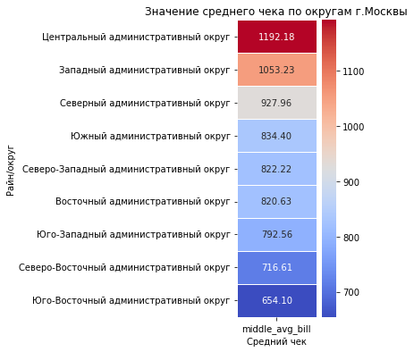

```python
# Создаём тепловую карту значений среднего чека
plt.figure(figsize=(2, 6))
sns.heatmap(bill_price, annot=True, fmt='.2f', cmap='coolwarm', linewidths=0.5, cbar=True)
plt.title('Значение среднего чека по округам г.Москвы')
plt.xlabel('Средний чек')
plt.ylabel('Райн/округ')
# Выводим график
plt.show()
```

Видим, что самый высокий средний чек - в Центральном районе - 1192,18 руб, Самый низкий - в Юго-Восточном.

Визуализируем значение среднего чека по каждому округу диаграммой barplot.

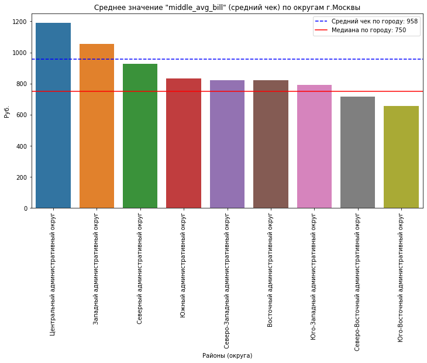

```python
#Расчет средней и медианы ср. чека по всем округам
mean_bill = bill['middle_avg_bill'].mean()
median_bill = bill['middle_avg_bill'].median()

#сброс индекса для того, чтобы по столбцу построить график
bill_price=bill_price.reset_index()
# Построим график
plt.figure(figsize=(12, 6))
#sns.barplot(data=bill_price, x="district", y="middle_avg_bill", palette='tab20b') - для разных версий seaborn
sns.barplot(data=bill_price, x="district", y="middle_avg_bill", hue="district")
#повернем подписи на оси x, т.к. не умещаются по горизонтали
plt.xticks(rotation=90)
# Добавление линий среднего чека и его медианы
plt.axhline(mean_bill, color="blue", linestyle="--", label=f'Средний чек по городу: {mean_bill:.0f}')
plt.axhline(median_bill,color="red",linestyle="-", label=f'Медиана по городу: {median_bill:.0f}')
plt.legend()
plt.title('Среднее значение "middle_avg_bill" (средний чек) по округам г.Москвы' )
plt.xlabel('Районы (округа)')
plt.ylabel('Руб.')
plt.show()
```

Посмотрим насколько сильно отличается средний чек в заведениях разной ценовой политики по районам города. Для наглядности построим тепловую карту.

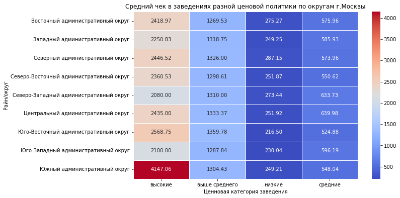

```python
#Строим сводную таблицу по району, ценовой политике и вычислим средний чек
bill_price = pd.pivot_table(bill, index=['district'], columns=['price'], values='middle_avg_bill', aggfunc='mean')

#коммент для себя - то же самое можно сделать группировкой
#bill_price = bill.groupby(['district','price'])['middle_avg_bill'].mean().unstack(fill_value=0)

# Создаём тепловую карту значений
plt.figure(figsize=(10, 6))
sns.heatmap(bill_price, annot=True, fmt='.2f', cmap='coolwarm', linewidths=0.5, cbar=True)
plt.title('Средний чек в заведениях разной ценовой политики по округам г.Москвы')
plt.xlabel('Ценновая категория заведения')
plt.ylabel('Райн/округ')
# Выводим график
plt.show()
```

**Вывод:** Самый высокий средний чек - в Центральном округе - 1192,18. Самый низкий - в Юго-Восточном - 654.1.

По тепловой карте значений среднего чека, ценовой политики и района можно увидеть выбивающееся значение в заведениях с высокой ценовой категорией в Южном округе (можно, в дальнейшем изучить данные подробнее).

В целом по тепловой карте можно скзать, что значение среднего чека в заведениях с ценовой политикой: низкая, средняя и выше среднего от района не зависит - ячейки практически одного цвета. А в заведениях с высокими ценами - есть вариации. Самый высокий средний чек в заведениях с высокой ценовой политикой: в Южном округе (4147,06), самый низкий - в Северо-Западном - 2080,0 руб.